# TODO: Title

## Model Profiling and Debugging

TODO: Using the best hyperparameters, create and finetune a new model

**Note:** You will need to use the `train_model.py` script to perform model profiling and debugging.

```python
# TODO: Set up debugging and profiling rules and hooks
from sagemaker.debugger import (
    Rule,
    DebuggerHookConfig,
    rule_configs,
    ProfilerConfig,
    ProfilerRule,
    FrameworkProfile,
    CollectionConfig
)

rules = [
    Rule.sagemaker(rule_configs.vanishing_gradient()),
    Rule.sagemaker(rule_configs.overfit()),
    Rule.sagemaker(rule_configs.overtraining()),
    Rule.sagemaker(rule_configs.poor_weight_initialization()),
    Rule.sagemaker(rule_configs.loss_not_decreasing()),
    ProfilerRule.sagemaker(rule_configs.LowGPUUtilization()),
    ProfilerRule.sagemaker(rule_configs.ProfilerReport()),

]
# collection_configs=[
#     CollectionConfig(
#         name="my_losses",
#         parameters={
#             "train.save_steps": "100",
#             "eval.save_steps": "30"
#         }
#     )
# ]



# hook_config = DebuggerHookConfig(
#     hook_parameters={"train.save_interval": "10", "eval.save_interval": "10"},
#     collection_configs=collection_configs
# )

collection_configs=[CollectionConfig(name="CrossEntropyLoss_output_0",parameters={
    "include_regex": "CrossEntropyLoss_output_0", "train.save_interval": "10","eval.save_interval": "10"})]
debugger_config=DebuggerHookConfig(
    collection_configs=collection_configs
)


# hook_config = DebuggerHookConfig(
#                 hook_parameters={"save_interval": '100'},
#                                collection_configs=[
#                                CollectionConfig("losses"),
#                                CollectionConfig("weights"),
#                                CollectionConfig("gradients"),
#                                CollectionConfig("biases")]
#                             )


profiler_config = ProfilerConfig(
    system_monitor_interval_millis=500, framework_profile_params=FrameworkProfile(num_steps=1)
)

hyperparameters = {"epochs": "20", "momentum":"0.982283732924826", "batch-size": "128", "test-batch-size": "512", "lr": "0.0058033510061050175"}
```

```python
# TODO: Create and fit an estimator

estimator = PyTorch(
    entry_point="train_model.py",
    base_job_name="smdebugger-pytorch",
    role=role,
    instance_count=1,
    instance_type="ml.p3.2xlarge",
    hyperparameters=hyperparameters,
    framework_version="1.12",
    py_version="py38",
    ## Debugger parameters
    rules=rules,
    debugger_hook_config=debugger_config,
    profiler_config=profiler_config
)
estimator.fit({'train': 's3://' + bucket + '/data/train',
               'valid': 's3://' + bucket + '/data/valid',
               'test': 's3://' + bucket + '/data/test'}, wait=True)

job_name = estimator.latest_training_job.name
client = estimator.sagemaker_session.sagemaker_client
description = client.describe_training_job(TrainingJobName=estimator.latest_training_job.name)
```

[output not shown]

[output cut: 246 more lines]

```
2023-01-22 01:17:36,489 sagemaker-training-toolkit INFO     Waiting for the process to finish and give a return code.
2023-01-22 01:17:36,489 sagemaker-training-toolkit INFO     Done waiting for a return code. Received 0 from exiting process.
2023-01-22 01:17:36,490 sagemaker-training-toolkit INFO     Reporting training SUCCESS

2023-01-22 01:17:55 Uploading - Uploading generated training model
2023-01-22 01:18:28 Completed - Training job completed
VanishingGradient: InProgress
Overfit: InProgress
Overtraining: InProgress
PoorWeightInitialization: NoIssuesFound
LossNotDecreasing: InProgress
LowGPUUtilization: IssuesFound
ProfilerReport: IssuesFound
Training seconds: 1870
Billable seconds: 1870
```

```python
print(job_name)
```

```
smdebugger-pytorch-2023-01-22-00-45-09-640
```

```python
# TODO: Plot a debugging output.
from smdebug.trials import create_trial
from smdebug.core.modes import ModeKeys
import matplotlib.pyplot as plt
from mpl_toolkits.axes_grid1 import host_subplot

trial = create_trial(estimator.latest_job_debugger_artifacts_path())
print(trial.tensor_names())

def get_data(trial, tname, mode):
    tensor = trial.tensor(tname)
    steps = tensor.steps(mode=mode)
    vals = []
    for s in steps:
        vals.append(tensor.value(s, mode=mode))
    return steps, vals

def plot_tensor(trial, tensor_name):

    steps_train, vals_train = get_data(trial, tensor_name, mode=ModeKeys.TRAIN)
    print(steps_train)
    print("loaded TRAIN data")
    steps_eval, vals_eval = get_data(trial, tensor_name, mode=ModeKeys.EVAL)
    print("loaded EVAL data")
    print(steps_eval, vals_eval)

    fig = plt.figure(figsize=(10, 7))
    host = host_subplot(111)

    par = host.twiny()

    host.set_xlabel("Steps (TRAIN)")
    par.set_xlabel("Steps (EVAL)")
    host.set_ylabel(tensor_name)

    (p1,) = host.plot(steps_train, vals_train, label=tensor_name)
    print("completed TRAIN plot")
    (p2,) = par.plot(steps_eval, vals_eval, label="val_" + tensor_name)
    print("completed EVAL plot")
    leg = plt.legend()

    host.xaxis.get_label().set_color(p1.get_color())
    leg.texts[0].set_color(p1.get_color())

    par.xaxis.get_label().set_color(p2.get_color())
    leg.texts[1].set_color(p2.get_color())

    plt.ylabel(tensor_name)

    plt.show()
```

[output not shown]

```python
print(len(trial.tensor("CrossEntropyLoss_output_0").steps(mode=ModeKeys.TRAIN)))
print(len(trial.tensor("CrossEntropyLoss_output_0").steps(mode=ModeKeys.EVAL)))
```

```
106
5
```

```python
trial.tensor_names()
```

```
['CrossEntropyLoss_output_0',
 'gradient/Inception3_fc.0.bias',
 'gradient/Inception3_fc.0.weight',
 'gradient/Inception3_fc.2.bias',
 'gradient/Inception3_fc.2.weight',
 'gradient/Inception3_fc.4.bias',
 'gradient/Inception3_fc.4.weight']
```

```
[0, 10, 20, 30, 40, 50, 60, 70, 80, 90, 100, 110, 120, 130, 140, 150, 160, 170, 180, 190, 200, 210, 220, 230, 240, 250, 260, 270, 280, 290, 300, 310, 320, 330, 340, 350, 360, 370, 380, 390, 400, 410, 420, 430, 440, 450, 460, 470, 480, 490, 500, 510, 520, 530, 540, 550, 560, 570, 580, 590, 600, 610, …
loaded TRAIN data
loaded EVAL data
[0, 10, 20, 30, 40] [array(4.83333, dtype=float32), array(1.1079887, dtype=float32), array(0.66607255, dtype=float32), array(0.6244983, dtype=float32), array(0.6126464, dtype=float32)]
completed TRAIN plot
completed EVAL plot
```

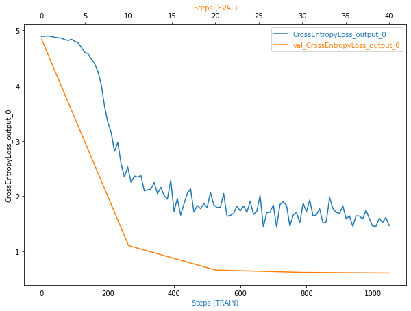

```python
plot_tensor(trial, 'CrossEntropyLoss_output_0')
```

**TODO**: Is there some anomalous behaviour in your debugging output? If so, what is the error and how will you fix it?  
**TODO**: If not, suppose there was an error. What would that error look like and how would you have fixed it?

- THe chart looks good. for overfitting, we might need to use more data, or change to a less complex model. For vanishing gradient, we can add batch normalization layer. for loss not decrease, we might need to fine tune hyperparameters.

```python
# TODO: Display the profiler output

from smdebug.profiler.analysis.notebook_utils.training_job import TrainingJob
tj = TrainingJob(job_name, region)
tj.wait_for_sys_profiling_data_to_be_available()
print(f"Training jobname: {job_name}")
print(f"Region: {region}")

from smdebug.profiler.analysis.notebook_utils.timeline_charts import TimelineCharts

system_metrics_reader = tj.get_systems_metrics_reader()
system_metrics_reader.refresh_event_file_list()

view_timeline_charts = TimelineCharts(
    system_metrics_reader,
    framework_metrics_reader=None,
    select_dimensions=["CPU", "GPU"],
    select_events=["total"],
)

rule_output_path = estimator.output_path + estimator.latest_training_job.job_name + "/rule-output"
print(f"You will find the profiler report in {rule_output_path}")
```

```
ProfilerConfig:{'S3OutputPath': 's3://sagemaker-us-east-1-122813631061/', 'ProfilingIntervalInMilliseconds': 500, 'ProfilingParameters': {'DataloaderProfilingConfig': '{"StartStep": 0, "NumSteps": 1, "MetricsRegex": ".*", }', 'DetailedProfilingConfig': '{"StartStep": 0, "NumSteps": 1, }', 'FileOpenF…
s3 path:s3://sagemaker-us-east-1-122813631061/smdebugger-pytorch-2023-01-22-00-45-09-640/profiler-output


Profiler data from system is available
Training jobname: smdebugger-pytorch-2023-01-22-00-45-09-640
Region: us-east-1
[2023-01-22 01:21:39.494 pytorch-1-12-cpu-py38-ml-t3-medium-f8be1a063b37f44eb7b009d8cbea:81 INFO metrics_reader_base.py:134] Getting 31 event files
select events:['total']
select dimensions:['CPU', 'GPU']
filtered_events:{'total'}
filtered_dimensions:{'GPUMemoryUtilization-nodeid:algo-1', 'CPUUtilization-nodeid:algo-1', 'GPUUtilization-nodeid:algo-1'}
```

[interactive chart not shown]

```
You will find the profiler report in s3://sagemaker-us-east-1-122813631061/smdebugger-pytorch-2023-01-22-00-45-09-640/rule-output
```

```python
! aws s3 ls {rule_output_path} --recursive
```

```
2023-01-22 01:17:58     409972 smdebugger-pytorch-2023-01-22-00-45-09-640/rule-output/ProfilerReport/profiler-output/profiler-report.html
2023-01-22 01:17:57     264366 smdebugger-pytorch-2023-01-22-00-45-09-640/rule-output/ProfilerReport/profiler-output/profiler-report.ipynb
2023-01-22 01:17:52        192 smdebugger-pytorch-2023-01-22-00-45-09-640/rule-output/ProfilerReport/profiler-output/profiler-reports/BatchSize.json
2023-01-22 01:17:53      92242 smdebugger-pytorch-2023-01-22-00-45-09-640/rule-output/ProfilerReport/profiler-output/profiler-reports/CPUBottleneck.json
2023-01-22 01:17:53       1771 smdebugger-pytorch-2023-01-22-00-45-09-640/rule-output/ProfilerReport/profiler-output/profiler-reports/Dataloader.json
2023-01-22 01:17:53        327 smdebugger-pytorch-2023-01-22-00-45-09-640/rule-output/ProfilerReport/profiler-output/profiler-reports/GPUMemoryIncrease.json
2023-01-22 01:17:53        830 smdebugger-pytorch-2023-01-22-00-45-09-640/rule-output/ProfilerReport/profiler-output/profiler-reports/IOBottleneck.json
2023-01-22 01:17:53        349 smdebugger-pytorch-2023-01-22-00-45-09-640/rule-output/ProfilerReport/profiler-output/profiler-reports/LoadBalancing.json
2023-01-22 01:17:53        337 smdebugger-pytorch-2023-01-22-00-45-09-640/rule-output/ProfilerReport/profiler-output/profiler-reports/LowGPUUtilization.json
2023-01-22 01:17:53        233 smdebugger-pytorch-2023-01-22-00-45-09-640/rule-output/ProfilerReport/profiler-output/profiler-reports/MaxInitializationTime.json
2023-01-22 01:17:53        376 smdebugger-pytorch-2023-01-22-00-45-09-640/rule-output/ProfilerReport/profiler-output/profiler-reports/OverallFrameworkMetrics.json
2023-01-22 01:17:53        613 smdebugger-pytorch-2023-01-22-00-45-09-640/rule-output/ProfilerReport/profiler-output/profiler-reports/OverallSystemUsage.json
2023-01-22 01:17:53       2213 smdebugger-pytorch-2023-01-22-00-45-09-640/rule-output/ProfilerReport/profiler-output/profiler-reports/StepOutlier.json
```

```python
! aws s3 cp {rule_output_path} ./ --recursive
```

[output not shown]

```python
import os

# get the autogenerated folder name of profiler report
profiler_report_name = [
    rule["RuleConfigurationName"]
    for rule in estimator.latest_training_job.rule_job_summary()
    if "Profiler" in rule["RuleConfigurationName"]
][0]
```

```python
import IPython

IPython.display.IFrame(src=profiler_report_name + "/profiler-output/profiler-report.html", width="100%", height="300")
```

[interactive chart not shown]

## Model Deploying

```python
from sagemaker.pytorch import PyTorchModel
from sagemaker.predictor import Predictor

jpeg_serializer = sagemaker.serializers.IdentitySerializer("image/jpeg")
json_deserializer = sagemaker.deserializers.JSONDeserializer()

class ImagePredictor(Predictor):
    def __init__(self, endpoint_name, sagemaker_session):
        super(ImagePredictor, self).__init__(
            endpoint_name,
            sagemaker_session=sagemaker_session,
            serializer=jpeg_serializer,
            deserializer=json_deserializer,
        )



pytorch_model = PyTorchModel(model_data='s3://sagemaker-us-east-1-122813631061/smdebugger-pytorch-2023-01-22-00-45-09-640/output/model.tar.gz',
                             role=role,
                             entry_point='inference.py',
                             framework_version="1.9",
                             py_version = 'py38',
                             predictor_cls=ImagePredictor
                            )
```

```python
# TODO: Deploy your model to an endpoint

predictor = pytorch_model.deploy(instance_type='ml.g4dn.xlarge', initial_instance_count=1)
```

```
------------!
```

```python
# TODO: Run an prediction on the endpoint

image = "dogImages/test/002.Afghan_hound/Afghan_hound_00125.jpg"
with open(image, "rb") as f:
    payload = f.read()

type(payload)
response = predictor.predict(payload, initial_args={"ContentType": "image/jpeg"})
```

```python
response
```

[output not shown]

```python
# TODO: Remember to shutdown/delete your endpoint once your work is done
predictor.delete_endpoint()
```